# Differential Gene Expression Analysis and Preliminary ORA

BCB420 Assignment 2

Jielin Yang

March 14, 2023

# 1 Introduction

## 1.1 Background

Heart failure (HF) is a chronic cardiac disease with complex pathophysiology involving multiple factors. A major hallmark of HF is the progressive degeneration of the myocardium that is accompanied by cardiac fibrosis.<sup>1</sup> <sup>2</sup><sup>3</sup> The identification of profibrotic pathways are essential to the development of therapeutic strategies to delay or even to prevent the profibrotic remodelling of the heart.

Previous studies have found that mechanical stress on the cell cytoskeleton can induce the nuclear entry of the YAP/TAZ complex, which subsequently activates the proliferative pathways.<sup>4</sup> <sup>5</sup><sup>6</sup> Although such a mechanism may seem to be beneficial for the restoration of the damaged cardiomyocytes, this pathway has been shown to be more active in cardiac stromal cells, which can subsequently differentiate into myofibroblasts that eventually leads to the profibrotic remodelling of the heart.<sup>1</sup> Therefore, directly suppressing the YAP/TAZ complex in cardiac stromal cells may be an effective strategy. Recently, [Garoffolo et al.](https://www.ahajournals.org/doi/10.1161/CIRCRESAHA.121.319373) investigated the use of a small molecular inhibitor, verteporfin (VTP), to suppress the YAP/TAZ complex with or without the presence of TGF-β1, a profibrotic cytokine under the maximal strain condition.

## 1.2 Objectives

We aim to use RNA-seq data to identify the changes in the transcriptional profile of cardiac stromal cells after the use of VTP. Figure 1. shows the experimental design of the study. Here, we perform differential gene expression analysis comparing the transcriptome of the cells treated with VTP with control under the known profibrotic straining condition. Additionally, we test the efficacy of the drug (VTP) under the presence of TGF-β1, a potent profibrotic cytokine.<sup>7</sup> To investigate whether direct inhibition of the YAP/TAZ complex with VTP, we perform threshold over-representation analysis to identify enriched pathways in the differentially expressed genes, which would allow us to identify whether VTP can effectively reverse a profibrotic phenotype.

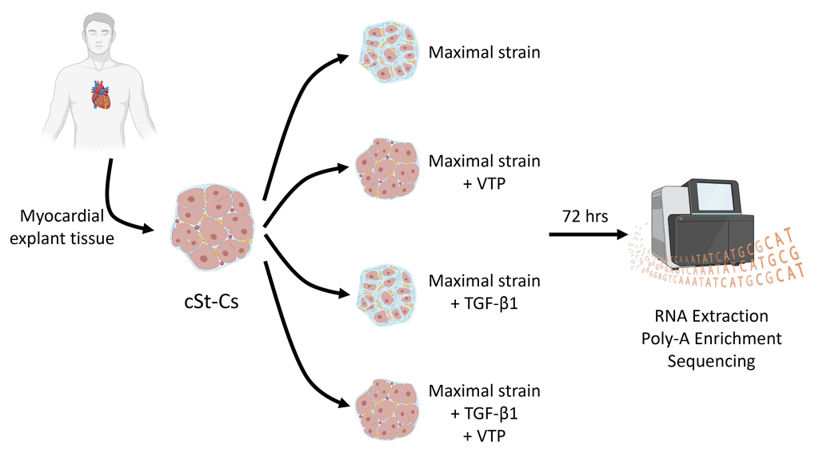

**Figure 1.** Schematics of RNAseq experiment design. Samples were cultured under maximal mechanical strains. Six independent cell cultures were used for each treatment condition. cSt-Cs: cardiospheres-derived primitive cardiac stromal cells; VTP: verteporfin; TGF-β1: transforming growth factor beta-1. Figure adapted from [Assignment 1](https://github.com/bcb420-2023/Jielin_Yang/blob/main/Dataset%20selection%20and%20initial%20processing/Assignment_1_Data_cleaning_and_identifier_mapping.html) and created with BioRender.com.

## 1.3 Dataset

The data used in the present analysis is retrieved from the GEO database under the accession number GSE203358. The dataset contains RNA-seq data from 24 samples, which are evenly split into 4 groups: - Control (maximal strain condition) - Verteporfin (VTP) treatment (maximal strain condition) - TGF-β1 treatment (maximal strain condition) - Verteporfin (VTP) treatment with TGF-β1 (maximal strain condition)

## 1.4 Previous Analysis

Since we have previously performed initial data cleaning and normalization, here we provide a brief summary of the previous analysis. The entire process can be found [here](https://github.com/bcb420-2023/Jielin_Yang/blob/main/Dataset%20selection%20and%20initial%20processing/Assignment_1_Data_cleaning_and_identifier_mapping.html).

### 1.4.1 Data QC and Filtering

The original dataset is composed of `24` samples and `60583`genes. After removing genes with low counts, the dataset we use in the present analysis is composed of `14814` genes. The reference genome used is the human [GRCh38](https://useast.ensembl.org/Homo_sapiens/Info/Index?db=core).

### 1.4.2 Identifier Mapping and Normalization

The original dataset contains a mix of HUGO gene symbols and GenBank identifiers. We used the [biomaRt](https://bioconductor.org/packages/release/bioc/html/biomaRt.html) package to map the rest of the identifiers to HUGO gene symbols.<sup>8</sup> The dataset was normalized using the Trimmed Mean of M-values (TMM) method implemented by the [edgeR](https://bioconductor.org/packages/release/bioc/html/edgeR.html) package.<sup>9</sup> After applying normalization, the library size for each sample has been effectively adjusted such that the distribution of gene expressions are comparable across samples.

### 1.4.3 Multidimensional Scaling

We evaluated the variance between the samples by accessing the clustering of the samples using multidimensional scaling (MDS). The MDS plot shown in [Assignment 1](https://github.com/bcb420-2023/Jielin_Yang/blob/main/Dataset%20selection%20and%20initial%20processing/Assignment_1_Data_cleaning_and_identifier_mapping.html) reveals a moderate clustering of samples based on the treatment conditions, and in particular, the control samples under mechanical strain alone are clustered separately with any other groups. The other treatment groups show less separation along either the dimension, but clustering is still observed. Interestingly, although most of the samples are clustered based on the treatment conditions and that we did not observe obvious clustering based on the cell culture replicates, we notice that certain samples that do not cluster tightly with the rest in the same treatment group seem to be consistent across the conditions. For example, comparing to other replicates, in cells from culture `M89` and `M99`, different conditions seem to have a smaller effect on the gene expression profile.

# 2 Preparations

## 2.1 Package Dependencies

The current R Notebook assumes that it is being run on the BCB420-2023 base image. Additional packages required are noted below. For reproducibility we list all packages we used in the analysis, including utility packages.

```r
# edgeR package for manupulating and analyzing RNAseq data
if (!requireNamespace("edgeR", quietly = TRUE)) {
    BiocManager::install("edgeR")
}
# limma package for differential expression analysis
if (!requireNamespace("limma", quietly = TRUE)) {
    BiocManager::install("limma")
}
# ComplexHeatmap package for creating heatmaps
if (!requireNamespace("ComplexHeatmap", quietly = TRUE)) {
    BiocManager::install("ComplexHeatmap")
}
# circlize package for circular visualization
if (!requireNamespace("circlize", quietly = TRUE)) {
    BiocManager::install("circlize")
}
# ggplot2 package for creating plots
if (!requireNamespace("ggplot2", quietly = TRUE)) {
    install.packages("ggplot2")
}
# cowplot package for arranging plots
if (!requireNamespace("cowplot", quietly = TRUE)) {
    install.packages("cowplot")
}
# ggrepel package for plotting text with minimal overlap
if (!requireNamespace("ggrepel", quietly = TRUE)) {
    install.packages("ggrepel")
}
# KableExtra package for creating tables and formatting
if (!requireNamespace("kableExtra", quietly = TRUE)) {
    install.packages("kableExtra")
}
# dplyr package for data manipulation
if (!requireNamespace("dplyr", quietly = TRUE)) {
    install.packages("dplyr")
}
# DT package for creating interactive tables
if (!requireNamespace("DT", quietly = TRUE)) {
    install.packages("DT")
}

# Load the packages
library("dplyr")
library("ggplot2")

# We will consistently use package::function() to avoid confusion However, the dplyr package has to be
# loaded first to allow definitions of various operators such as %>%
```

## 2.2 Data Import

In the previous analysis, we have saved the processed data output to a file. Hence, we can simply load the data from the file and perform the analysis.

```r
# Load the processed data
counts <- read.csv(file = "./Data/expr_norm_counts.csv", header = TRUE, row.names = 1)

# View the first few rows of the data
head(counts)
```

|  | M04.CTRL | M04.TGFb | M04.TGFb_VTP | M04.VTP | M77.CTRL | M77.TGFb | M77.TGFb_VTP | M77.VTP | M78.CTRL | M78.TGFb | M78.TGFb_VTP | M78.VTP | M81.CTRL | M81.TGFb | M81.TGFb_VTP | M81.VTP | M89.CTRL | M89.TGFb | M89.TGFb_VTP | M89.VTP | M99.CTRL | M99.TGFb | M99.TGFb_VTP | M99.VTP |
| --- | --- | --- | --- | --- | --- | --- | --- | --- | --- | --- | --- | --- | --- | --- | --- | --- | --- | --- | --- | --- | --- | --- | --- | --- |
| A1BG-AS1 | 193 | 197 | 125 | 271 | 168 | 221 | 272 | 167 | 48 | 59 | 84 | 44 | 144 | 174 | 267 | 199 | 125 | 236 | 185 | 180 | 178 | 167 | 196 | 118 |
| A4GALT | 419 | 346 | 260 | 936 | 300 | 274 | 308 | 297 | 571 | 404 | 468 | 416 | 418 | 263 | 303 | 325 | 135 | 372 | 323 | 744 | 270 | 293 | 428 | 152 |
| AAAS | 469 | 448 | 379 | 990 | 357 | 401 | 766 | 519 | 469 | 345 | 573 | 300 | 539 | 530 | 881 | 645 | 271 | 634 | 477 | 719 | 402 | 407 | 754 | 292 |
| AACS | 685 | 737 | 535 | 1240 | 717 | 947 | 1298 | 779 | 1030 | 834 | 1448 | 498 | 714 | 1011 | 1329 | 808 | 585 | 1034 | 929 | 897 | 796 | 740 | 1054 | 489 |
| AADAT | 42 | 61 | 52 | 55 | 84 | 77 | 154 | 69 | 80 | 53 | 108 | 55 | 46 | 65 | 134 | 84 | 63 | 92 | 87 | 54 | 72 | 39 | 54 | 71 |
| AAGAB | 557 | 707 | 674 | 720 | 420 | 595 | 807 | 522 | 572 | 454 | 744 | 199 | 474 | 675 | 960 | 683 | 446 | 769 | 626 | 309 | 578 | 467 | 410 | 372 |

**Table 1.** Processed count data used for the present analysis. The data is composed of 14814 genes and 24 samples, where each gene is identified by a unique HUGO symbol. The first few rows are shown.

Since the header of the data contains the sample information, we will extract the sample information from the header to reconstruct the experimental design.

```r
# Extract the sample information from the header
sample_matrix <- colnames(counts) %>%
    lapply(function(x) {
        unlist(strsplit(x, split = "\\."))
    }) %>%
    as.data.frame()

# Rename the data frame
colnames(sample_matrix) <- colnames(counts)
rownames(sample_matrix) <- c("culture", "treatment")

# Transpose the data frame so that each row represents a unique sample and each column represents a unique
# sample attribute
sample_matrix <- data.frame(t(sample_matrix))

# View the sample information
DT::datatable(sample_matrix[order(sample_matrix$treatment), ], rownames = TRUE, filter = "top", options = list(pageLength = 6)) %>%
    # Changing the font size of content
DT::formatStyle(names(sample_matrix), fontSize = "12px") %>%
    # Changing the font size of row names (sample names)
DT::formatStyle(0, fontSize = "12px")
```

|  | culture | treatment |
| --- | --- | --- |
| M04.CTRL | M04 | CTRL |
| M77.CTRL | M77 | CTRL |
| M78.CTRL | M78 | CTRL |
| M81.CTRL | M81 | CTRL |
| M89.CTRL | M89 | CTRL |
| M99.CTRL | M99 | CTRL |
| M04.TGFb | M04 | TGFb |
| M77.TGFb | M77 | TGFb |
| M78.TGFb | M78 | TGFb |
| M81.TGFb | M81 | TGFb |

[output cut: 14 more lines]

**Table 2.** Sample information used for the present analysis. A total of 24 samples are included in the analysis, where each sample is identified by a unique culture ID and treatment condition. Cells are retrieved from 6 independent cultures, and each is used for 4 different treatment conditions.

# 3 Differential Gene Expression Analysis

Understanding the antifibrotic effect of VTP requires a comprehensive analysis of the gene expression profile of the cSt-Cs by identifying the transcriptional changes with or without the treatment of VTP. To this end, we will perform two separate differential gene expression analysis with and without the presence of TGF-β1, in which we can isolate the effect of VTP as the only independent variable.

## 3.1 Global Gene Expression Profiling

Before performing differential gene expression analysis, we first want to observe the global expression change at the gene level. Here, we plot a heatmap for all the genes in the dataset to visualize the expression change across all samples under various conditions.

```r
# Creating a DGEList object
counts_dge <- edgeR::DGEList(counts = counts, group = sample_matrix$treatment)

# As discussed in the associated journal entry, the data we use are the counts, rather than the counts per
# million (CPM) values. Therefore, we will need to convert the count to CPM values for normalization on
# library size before plotting the heatmap.
counts_dge <- edgeR::calcNormFactors(counts_dge)
counts_cpm_all <- edgeR::cpm(counts_dge)
```

```r
# Create a heatmap matrix for all the genes by scaling the CPM values This allows the heatmap colour to be
# on a consistent and continuous scale across all the samples
heatmap_matrix <- counts_cpm_all %>%
    t() %>%
    scale() %>%
    t()
```

```r
# Checking the range of the heatmap matrix
hmap_range <- range(heatmap_matrix)
```

Here, heatmap creation and visual representation are implemented using the `ComplexHeatmap` and `circlize` packages, respectively.<sup>11</sup> <sup>12</sup>

```r
# Set the 3 color palette based on the scaled heatmap matrix
hmap_col <- circlize::colorRamp2(c(hmap_range[1], 0, hmap_range[2]), c("blue", "white", "red"))
```

Due to the relatively large number of samples, we will also apply annotations to the heatmap to better visualize the clustering of the samples. In particular, we will annotate the heatmap by the treatment condition and culture replicate. This would better allows us to identify whether any of the variables have a significant effect on the clustering of the samples.

```r
# Sort the sample matrix in the same order as the heatmap matrix
sample_matrix_sorted <- sample_matrix[colnames(heatmap_matrix), ]

# Treatment Conditions
treatments <- unique(sample_matrix_sorted$treatment)
# Define 4 colours for the 4 treatment conditions
treatment_col <- hcl.colors(4, palette = "viridis")
names(treatment_col) <- treatments

# Culture Replicates
cultures <- unique(sample_matrix_sorted$culture)
# Define 6 colours for the 6 culture replicates
culture_col <- hcl.colors(6, palette = "set3")
names(culture_col) <- cultures

# Create an annotation dataframe
anno_df <- data.frame(treatment = sample_matrix_sorted$treatment, culture = sample_matrix_sorted$culture)
anno_col <- list(treatment = treatment_col, culture = culture_col)
# Create the heatmap annotation
hmap_anno <- ComplexHeatmap::HeatmapAnnotation(df = anno_df, col = anno_col)
```

To better visualize the heatmap, we cluster the genes into 4 groups using the k-means clustering algorithm. This allows the genes that have similar expression profiles to be grouped together.<sup>13</sup> <sup>11</sup> Additionally, since our dataset consists of 4 treatment conditions, it is expected that a clustering of 4 groups will reveal some interesting patterns in the expression profiles.

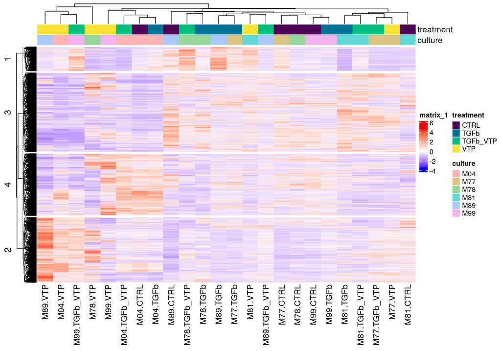

```r
# Generate the heatmap Set the seed for reproducibility due to he inherent randomness of the k-means
# clustering algorithm
set.seed(91711)
hmap_all <- ComplexHeatmap::Heatmap(heatmap_matrix, show_row_dend = TRUE, show_column_dend = TRUE, show_column_names = TRUE,
    show_row_names = FALSE, col = hmap_col, top_annotation = hmap_anno, km = 4)
set.seed(NULL)
# Plot the heatmap
hmap_all
```

**Figure 2.** Heatmap of global gene expression across all samples of different treatments. A k-mean clustering of 4 groups was applied to the heatmap for clusterization of gene with similar expression profiles. Samples are hierarchically clustered by their expression profiles. The top bar annotate the samples by treatment conditions and the culture in which the cells were extracted.

The 4 groups of genes generated by the k-means clustering algorithm show comparatively distinct expression profiles that define 4 subset (cluster) of samples. However, each of the 4 groups of samples (as indicated by the dendrogram) consists of a mix of samples from different treatment conditions. Based on the observation, we would not expect a very high number of differentially expressed gene between the conditions. However, despite the mix of treatment conditions within each cluster, it is still observable that samples under certain conditions tend to cluster together. For example, the left most cluster consists of samples that are treated with VTP. We can also observe a clustering of a subset of control cells and those that are treated with TGF-β1 alone. Since these two conditions are expected to show a profibrotic transcriptional programme, it is expected that these cells share similar expression patterns.

In addition, the annotation based on the culture replicate also shows a moderate clustering of the samples taken from the same cSt-Cs culture. This means that the culture in which the cells were extract likely contributes to the variance in the gene expression. The observation here using the heatmap is consistent with the distribution of the samples from the MDS plot. Therefore, we will take this into account when we perform build the model for differential expression analysis.

## 3.2 Model Selection

For differential gene expression analysis, we use the `edgeR` package, which implements a generalized linear model (GLM) to test for differential expression.<sup>9</sup> Based on the objective of our analysis, we will build the model based on the treatment conditions. Additionally, since we have observed a subset of cultures replicates that tend to show similar expression pattern based on culture number (Figure 2.), it is expected that the culture replicate will also contribute to the variance in gene expression. Therefore, we choose the model to include both factors, treatment and culture replicate.

```r
# Extract the factors for the model
treatments <- sample_matrix$treatment
cultures <- sample_matrix$culture

# Create the model
model_treat_cul <- model.matrix(~0 + treatments + cultures)
rownames(model_treat_cul) <- rownames(sample_matrix)

# View the model matrix, ordered by treatment condition
DT::datatable(model_treat_cul[order(gsub("M[0-9]{2}\\.", "", rownames(model_treat_cul))), ], rownames = TRUE,
    options = list(pageLength = 6, scrollX = TRUE)) %>%
    DT::formatStyle(names(model_treat_cul), fontSize = "12px")
```

|  | treatmentsCTRL | treatmentsTGFb | treatmentsTGFb_VTP | treatmentsVTP | culturesM77 | culturesM78 | culturesM81 | culturesM89 | culturesM99 |
| --- | --- | --- | --- | --- | --- | --- | --- | --- | --- |
| M04.CTRL | 1 | 0 | 0 | 0 | 0 | 0 | 0 | 0 | 0 |
| M77.CTRL | 1 | 0 | 0 | 0 | 1 | 0 | 0 | 0 | 0 |
| M78.CTRL | 1 | 0 | 0 | 0 | 0 | 1 | 0 | 0 | 0 |
| M81.CTRL | 1 | 0 | 0 | 0 | 0 | 0 | 1 | 0 | 0 |
| M89.CTRL | 1 | 0 | 0 | 0 | 0 | 0 | 0 | 1 | 0 |
| M99.CTRL | 1 | 0 | 0 | 0 | 0 | 0 | 0 | 0 | 1 |
| M04.TGFb | 0 | 1 | 0 | 0 | 0 | 0 | 0 | 0 | 0 |
| M77.TGFb | 0 | 1 | 0 | 0 | 1 | 0 | 0 | 0 | 0 |
| M78.TGFb | 0 | 1 | 0 | 0 | 0 | 1 | 0 | 0 | 0 |
| M81.TGFb | 0 | 1 | 0 | 0 | 0 | 0 | 1 | 0 | 0 |

[output cut: 14 more lines]

**Table 3.** Model design for differential expression analysis. The model includes both treatment and culture replicate as factors for fitting the generalized linear model.

Furthermore, `edgeR` implements dispersion estimation with the negative binomial model, which estimates the global variation across the samples in a biological group.<sup>14</sup> Correct estimation of dispersion not only allows accurate assessment of the quality of the data, but it is also a prerequisite for the differential expression analysis.<sup>14</sup> <sup>9</sup> Here we estimate and assess the dispersion using the `estimateDisp` function.

```r
# Estimate the dispersion
counts_dge <- edgeR::estimateDisp(counts_dge, model_treat_cul)
```

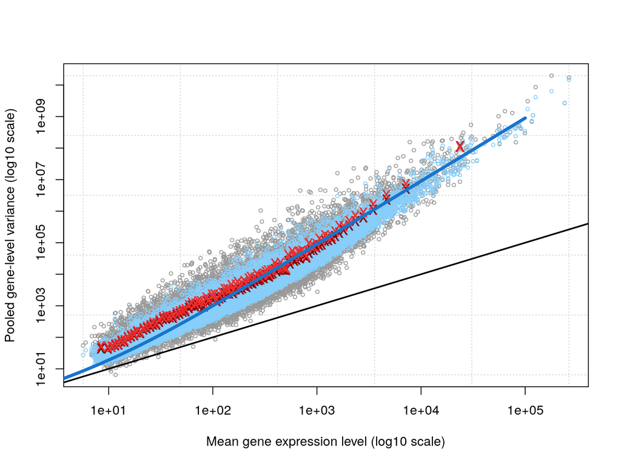

```r
# Plot the dispersion against the mean
edgeR::plotMeanVar(counts_dge, show.raw.vars = TRUE, show.tagwise.vars = TRUE, NBline = TRUE, show.binned.common.disp.vars = TRUE)
```

**Figure 3.** Mean-variance relationship of all genes across various treatment conditions. The dispersion is estimated using the negative binomial model. A blue line indicates a trended line based on the negative binomial model, with pooled and estimated gene-wise dispersion shown in gray and light blue, respectively. A black line with a slope of 1 represents the expected variance of a Poisson distribution, which assumes that the variance is equal to the mean.

Figure 3. illustrates the mean-variance relationship of the genes in the dataset across all genes and samples.<sup>15</sup> A trended line based on the negative binomial model shows an increasing variance correlating to higher mean expression, suggesting the existence of biological variation. The pooled gene-wise dispersion is similar to that of the estimated dispersion, and both of which align relatively closely with the trend line.

## 3.3 Differential Expression

Based on the model design and the estimated dispersion above, two differential gene expression analysis are performed separately, comparing the transcriptomic changes involved after the addition of VTP to the cells under maximal strain with and without the presence of TGF-β1. Here, we employ the gene-wise Quasi-likelihood F test with the negative binomial generalized linear model to test for differential expression. We choose the method because it has been suggested to account for gene-specific variations due to biological and technical factors and that it also reflects the uncertainty in dispersion estimation.<sup>14</sup> This is recommended for bulk RNA-seq dataset with a complex design (i.e., the two-factor model we employed in this analysis, as shown in Table 3).<sup>14</sup> <sup>9</sup>

### 3.3.1 Effect of VTP under Maximal Strain

First, we examine the effect of VTP in comparison to control without the presence of TGF-β1. Based on the model, we establish a contrast comparing the treatment of VTP alone to the control. This is implemented in the `limma` package.<sup>16</sup>

```r
# Create a contrast for VTP vs. control
contrast_vtp <- limma::makeContrasts("treatmentsVTP - treatmentsCTRL", levels = model_treat_cul)
```

We then perform the differential expression analysis by fitting the generalized linear model with the factors we designed and performing the Quasi-likelihood F test as described above.

```r
# Fit the model
glm_fit_treat_cul <- edgeR::glmQLFit(counts_dge, model_treat_cul)
# Perform the differential expression analysis
qlf_vtp_ctrl <- edgeR::glmQLFTest(glmfit = glm_fit_treat_cul, contrast = contrast_vtp)
```

```r
# Extract the results
results_vtp_ctrl <- edgeR::topTags(qlf_vtp_ctrl, sort.by = "PValue", n = nrow(counts_dge))$table
# Save the differential expression results
write.csv(results_vtp_ctrl, file = "./Data/dge_vtp_ctrl.csv", row.names = TRUE)
```

We will now examine the genes that are differentially expressed.

```r
# Differentially expressed genes based on unadjusted p-value
sum(results_vtp_ctrl$PValue < 0.05)
```

```
## [1] 3651
```

Among the `14814` genes in the dataset,`3651` are considered to be differentially expressed based on the unadjusted p-value with a threshold of 0.05. This is consistent with other RNA-seq studies that have a focus on heart gene expression.<sup>17</sup> Additionally, a threshold of 0.05 is also a common choice, since it is a conservative threshold that does not post a high risk of false positives and is not too stringent that may mask other biologically relevant genes.

Since paring RNA-seq expression data involves multiple hypothesis testing, we also adjust the p-values using the Benjamini-Hochberg method. This method assumes that the power to detect differential expression is equally likely among all the tests, which is suitable in the case of RNA-seq data, where the assumption is that most genes are not differentially expressed.<sup>18</sup>

```r
# Differentially expressed genes based on adjusted p-value
sum(results_vtp_ctrl$FDR < 0.05)
```

```
## [1] 1040
```

Ater adjusting for multiple hypothesis testing, a total of 1040 genes are considered to be truly differentially expressed. Since it is known that VTP is a direct inhibitor of the TAP/TAZ complex, which is involved in multiple pathways such as cell proliferation and migration, we expect that a certain amount of genes should be differentially expressed.<sup>1</sup> <sup>5</sup>

```r
# Retrieve the set of differentially expressed genes
deg_vtp_ctrl <- results_vtp_ctrl[results_vtp_ctrl$FDR < 0.05, ]
```

#### 3.3.1.1 Up-regulated Genes under VTP Treatment

```r
# Up-regulated genes
vtp_ctrl_up <- deg_vtp_ctrl[deg_vtp_ctrl$logFC > 0, ]
# We add gene symbol as a column so that it is searchable
vtp_ctrl_up$Gene = rownames(vtp_ctrl_up)
vtp_ctrl_up <- vtp_ctrl_up[, c(ncol(vtp_ctrl_up), 1:ncol(vtp_ctrl_up) - 1)]

# Sort by fold change and visualize with a table
vtp_ctrl_up <- vtp_ctrl_up[order(vtp_ctrl_up$logFC, decreasing = TRUE), ]
DT::datatable(vtp_ctrl_up, rownames = FALSE, filter = "top", options = list(pageLength = 5, scrollX = TRUE)) %>%
    # Changing the font size of content
DT::formatStyle(colnames(vtp_ctrl_up), fontSize = "12px") %>%
    # Changing the font size of row names (sample names)
DT::formatStyle(0, fontSize = "12px")
```

| Gene | logFC | logCPM | F | PValue | FDR |
| --- | --- | --- | --- | --- | --- |
| VWA5B2 | 3.36399516008247 | 2.7530836986188 | 22.0513149793403 | 0.000216764098341516 | 0.0161331960267193 |
| BCYRN1 | 3.28787168623464 | 6.09253875191142 | 12.228147914135 | 0.0023080713821294 | 0.041456250231853 |
| UNC13A | 2.63475563936814 | 0.8429760981874 | 18.6359984710414 | 0.000344660337958613 | 0.019188324703037 |
| SLC14A1 | 2.53729026878848 | 0.594948086749705 | 13.2286237313682 | 0.00166990322724352 | 0.0354660429493959 |
| PDE4C | 2.53397954283866 | 0.037307848469227 | 17.5976966191967 | 0.000457495490482129 | 0.0216528376869082 |
| NKD2 | 2.46864664838787 | 1.273165940224 | 28.1399173376028 | 3.58061164555187e-05 | 0.00870734777700307 |
| VSTM2L | 2.39505729703938 | 1.45100863781855 | 34.2155305743052 | 1.06607652186825e-05 | 0.00493526799842383 |
| RIMS4 | 2.3136200794875 | 0.472302022456493 | 14.13736557863 | 0.00125647050858249 | 0.0314899224325456 |
| SLC6A17 | 2.24680989616087 | 1.37668925277856 | 12.7385169651696 | 0.00241315677534155 | 0.0422170692326234 |
| ABCG2 | 2.23298216606515 | 1.34456478638648 | 14.078904749661 | 0.00127934266626661 | 0.0317087122008745 |

[output cut: 595 more lines]

**Table 4.** Up-regulated genes under VTP treatment comparing to control without TGF-β1.

#### 3.3.1.2 Down-regulated Genes under VTP Treatment

```r
# Down-regulated genes
vtp_ctrl_down <- deg_vtp_ctrl[deg_vtp_ctrl$logFC < 0, ]
# We add gene symbol as a column so that it is searchable
vtp_ctrl_down$Gene = rownames(vtp_ctrl_down)
vtp_ctrl_down <- vtp_ctrl_down[, c(ncol(vtp_ctrl_down), 1:ncol(vtp_ctrl_down) - 1)]

# Sort by fold change and visualize with a table
vtp_ctrl_down <- vtp_ctrl_down[order(vtp_ctrl_down$logFC, decreasing = FALSE), ]
DT::datatable(vtp_ctrl_down, rownames = FALSE, filter = "top", options = list(pageLength = 5, scrollX = TRUE)) %>%
    # Changing the font size of content
DT::formatStyle(colnames(vtp_ctrl_down), fontSize = "12px") %>%
    # Changing the font size of row names (sample names)
DT::formatStyle(0, fontSize = "12px")
```

| Gene | logFC | logCPM | F | PValue | FDR |
| --- | --- | --- | --- | --- | --- |
| COL11A1 | -4.17878421071618 | 2.06417107220048 | 49.7620570650987 | 8.3154570730848e-07 | 0.00203647068621716 |
| CCL11 | -3.96997463240744 | 2.03321445691215 | 42.9144491838504 | 2.35905686632672e-06 | 0.00232980456118427 |
| MAMDC2 | -3.78359921546367 | 5.67797041309973 | 13.8907637474759 | 0.00135613863246999 | 0.0324325635516029 |
| B3GALT2 | -3.14214647574021 | 1.66262688680626 | 35.3427185181093 | 8.64931229339864e-06 | 0.00418737146252528 |
| SAA1 | -3.07849795434297 | 0.655681968423931 | 13.9261268615429 | 0.00169951302157243 | 0.0355099942194273 |
| TNC | -3.03636351240172 | 5.89495100190489 | 24.1518052253463 | 8.68740974621847e-05 | 0.011916230368563 |
| CLSTN2 | -2.94625648457653 | 4.55303213536027 | 33.2915809798422 | 1.26970461547287e-05 | 0.00516226311682902 |
| SLC7A4 | -2.87311122504491 | -0.338081033335579 | 18.158483821958 | 0.000544841837232011 | 0.022800245697048 |
| TRPA1 | -2.71370570306106 | 0.382827394607952 | 20.3855112199312 | 0.000217810125917636 | 0.0161331960267193 |
| JAM2 | -2.69470960942066 | 1.80541817726248 | 26.2359439837094 | 5.41174351648005e-05 | 0.0102443249242247 |

[output cut: 425 more lines]

**Table 5.** Down-regulated genes under VTP treatment comparing to control without TGF-β1.

#### 3.3.1.3 Analysis and Visualization

Interestingly, we found `605` up-regulated genes, which is more than the number of down-regulated genes, `435`. The top upregulated genes are `VWA5B2, BCYRN1, UNC13A, SLC14A1, PDE4C`, which are not associated with fibrosis or cell proliferation. Rather, the top downregulated gene is `COL11A1`, with a fold change of `18.11`. This gene encodes [collagen type XI alpha 1 chain](https://useast.ensembl.org/Homo_sapiens/Gene/Summary?db=core;g=ENSG00000060718;r=1:102876467-103108872), which directly involves in the formation of collagen fibrils.<sup>19</sup> We can see that a total of `7` collagen genes are downregualed, with none of them upregulated. This suggests that VTP reduces the expression of collagen genes, which are the main components of fibrotic tissues. We also found that `P4HA1` gene is among the most significantly downregualted genes. The gene enxcodes a key subunit of the prolyl 4-hydroxylase complex, which is involved in a key step of collagen synthesis.<sup>20</sup> Among the upregulated genes, we found multiple `SLC` family genes, which are involved in membrane transport and are likely to contribute to cellular respirations, which are known to be reduced in fibrotic tissues.<sup>21</sup>

Here we visualize the differentially expressed genes using a Volcano plot, which allows for easy visualization of the genes accoding to their fold change and significance.

```r
# Label genes as up/down-regulated
results_vtp_ctrl <- results_vtp_ctrl %>%
    dplyr::mutate(Expression = dplyr::case_when(
                        logFC > 0 & FDR < 0.05 ~ "Up-regulated",
                        logFC < 0 & FDR < 0.05 ~ "Down-regulated",
                        TRUE ~ "Not DE"))

# Extract a sublist of inportant genes to label in the plot
# Subset differentially expressed genes
results_deg <- results_vtp_ctrl[results_vtp_ctrl$FDR < 0.05, ]

# 1. Collagen genes
genes_to_label <- results_deg[grepl("COL", rownames(results_deg)), ]
# 2. Prolyl 4-hydroxylase subunit
genes_to_label <- rbind(genes_to_label,
                        results_deg[grepl("P4HA1", rownames(results_deg)), ])
# 3. Top 3 up and down-regulated genes based on fold change
results_sort_by_FC <- results_deg[order(results_deg$logFC), ]
genes_to_label <- rbind(genes_to_label,
                results_sort_by_FC[1:3, ],
                results_sort_by_FC[(nrow(results_sort_by_FC)-2):nrow(results_sort_by_FC), ])

# Remove any duplicated genes in the subset
genes_to_label <- genes_to_label[!duplicated(rownames(genes_to_label)), ]
```

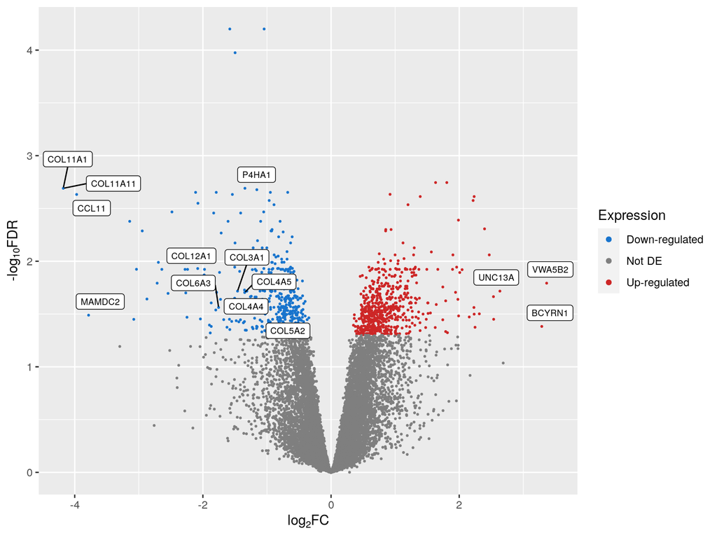

```r
# We will plot all genes, with highlighted genes representing the differentially expressed genes
# Color genes based on whether it is significantly up/down-regulated
# Label the genes of interest
ggplot2::ggplot(results_vtp_ctrl, aes(logFC, -log(FDR, 10))) +
    ggplot2::geom_point(aes(color = Expression), size = 2/5) +
    xlab(expression("log"[2]*"FC")) +
    ylab(expression("-log"[10]*"FDR")) +
    ggplot2::scale_color_manual(values = c("Up-regulated" = "firebrick3",
                                           "Down-regulated" = "dodgerblue3",
                                           "Not DE" = "gray50")) +
    ggplot2::guides(color = ggplot2::guide_legend(override.aes = list(size=1.5))) +
    ggrepel::geom_label_repel(data = genes_to_label,
                        mapping = aes(logFC, -log(FDR, 10), label = rownames(genes_to_label)),
                        size = 2.5, color = "black", nudge_x = 0.1, nudge_y = 0.1)
```

**Figure 4.** Volcano plot of differentially expressed genes comparing VTP treatment to control without TGF-β1. Differentially expressed genes are coloured based on direction of change. Genes of interest are labelled.

Figure 4. shows that the majority of the genes are not differentially expressed, with a few genes showing comparatively large fold change and significance. We can observe that the up and down-regulated genes are distributed evenly, except a few down-regualted genes showing very high significance. This is likely due to the fact that VTP is a drug the inhibits the YAP/TAZ complex, the downregulation of which likely leads to a reduction in multiple cellular processes related to fibrosis and extracellular matrix formation.<sup>22</sup>

To better visualize the differentially expressed genes between the two test condition, a heatmap is plotted to support the visualization of gene expression, and particularly the clustering of samples.

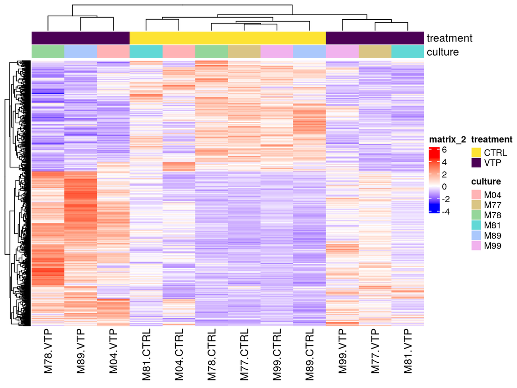

```r
# Extract the differentially expressed genes from the heatmap matrix
heatmap_matrix_vtp_ctrl <- heatmap_matrix[rownames(deg_vtp_ctrl), grepl("\\.VTP|\\.CTRL", colnames(heatmap_matrix))]
# Checking the range of the heatmap matrix
hmap_range <- range(heatmap_matrix_vtp_ctrl)
# Set the 3 color palette based on the scaled heatmap matrix
hmap_col <- circlize::colorRamp2(c(hmap_range[1], 0, hmap_range[2]), c("blue", "white", "red"))

# Redefine 2 colours for the 4 treatment conditions
treatment_col <- hcl.colors(2, palette = "viridis")
names(treatment_col) <- c("VTP", "CTRL")
# Create an annotation dataframe
anno_df <- data.frame(treatment = sample_matrix_sorted[grepl("\\.VTP|\\.CTRL", rownames(sample_matrix_sorted)),
    "treatment"], culture = sample_matrix_sorted[grepl("\\.VTP|\\.CTRL", rownames(sample_matrix_sorted)), "culture"])
anno_col <- list(treatment = treatment_col, culture = culture_col)
# Create the heatmap annotation
hmap_anno <- ComplexHeatmap::HeatmapAnnotation(df = anno_df, col = anno_col)

# Plot the heatmap
hmap_vtp_ctrl <- ComplexHeatmap::Heatmap(heatmap_matrix_vtp_ctrl, show_row_dend = TRUE, show_column_dend = TRUE,
    show_column_names = TRUE, show_row_names = FALSE, col = hmap_col, top_annotation = hmap_anno)
hmap_vtp_ctrl
```

**Figure 5.** Heatmap of differentially expressed genes comparing VTP treatment to control without TGF-β1. Samples are annotated based on treatment conditions and culture replicates.

Figure 5. reveals a clear clustering of samples based on the treatment conditions, in which all control samples display very similar set of up and down- regulated genes. This is consistant with the MDS plot we have generated previously. However interestingly, the dendrogram shows two distinct clusters of samples treated with VTP, located on the edge of the dendrogram. Comparing to the control samples, it is clear that the two clusters show consistent changes in up and down regulation of a defined set of genes, but the degree to which the change is observed is different. This is likely due to the fact that these are biological variations between the samples, or, possibly due to the effect of adding chemical compounds to the culture medium. As observed in the MDS plot from prior analysis and Figure 2, we observe a higher intra-condition variation once chemical compounds are added, in both cases of VTP and TGF-β1.

However, despite the clustering of samples, a clear pattern of up and down-regulated genes can be observed. In conjunction with the manual inspection of the top differentially expressed genes, VTP treatment alone under the profibrotic environment of mechanical strains has demonstrated anti-fibrotic effects by down-regulating collagen and ECM genes.

### 3.3.2 Effect of VTP under Maximal Strain with Profibrotic TGF-β1

Additionally, we want to investigate whether VTP can still negates the fibrotic effect under the potent profibrotic stimulus of TGF-β1. Therefore, we also establish a contrast comparing the treatment of VTP to control where both conditions are also subjected to the same TGF-β1 treatment.

```r
# Create a contrast for VTP vs. control with TGF-β1
contrast_vtp_tgf <- limma::makeContrasts("treatmentsTGFb_VTP - treatmentsTGFb", levels = model_treat_cul)
# Perform differential expression analysis
results_vtp_tgf <- edgeR::glmQLFTest(glmfit = glm_fit_treat_cul, contrast = contrast_vtp_tgf)
```

```r
# Extract the results
results_vtp_tgf <- edgeR::topTags(results_vtp_tgf, sort.by = "PValue", n = nrow(counts_dge))$table
# Save the differential expression results
write.csv(results_vtp_ctrl, file = "./Data/dge_vtp_tgf.csv", row.names = TRUE)
```

Based on unadjusted p-values, there are `1602` genes with unadjusted p-values less than `0.05`. There are `14` differentially expressed genes comparing VTP treatment to control in the presence of TGF-β1. Similar to the previous analysis, we used an threshold of `0.05` for the false discovery rate (FDR), as corrected by the Benjamini-Hochberg method, to determine whether a gene is considered differentially expressed. Among these differentially expressed genes, there are `3` genes that are up-regulated and `11` genes that are down-regulated, as shown below.

#### 3.3.2.1 Up-regulated Genes under VTP Treatment

```r
# Retrieve the set of differentially expressed genes
deg_vtp_tgf <- results_vtp_tgf[results_vtp_tgf$FDR < 0.05, ]
# Up-regulated genes
vtp_tgf_up <- deg_vtp_tgf[deg_vtp_tgf$logFC > 0, ]
# We add gene symbol as a column so that it is searchable
vtp_tgf_up$Gene <- rownames(vtp_tgf_up)
vtp_tgf_up <- vtp_tgf_up[, c(ncol(vtp_tgf_up), 1:(ncol(vtp_tgf_up) - 1))]

# Sort the genes by fold change and visualize using a table
vtp_tgf_up <- vtp_tgf_up[order(vtp_tgf_up$logFC, decreasing = TRUE), ]
DT::datatable(vtp_tgf_up, rownames = FALSE, filter = "top", options = list(pageLength = 5, scrollX = TRUE)) %>%
    DT::formatStyle(colnames(vtp_ctrl_up), fontSize = "12px") %>%
    DT::formatStyle(0, fontSize = "12px")
```

| Gene | logFC | logCPM | F | PValue | FDR |
| --- | --- | --- | --- | --- | --- |
| CYP1A1 | 2.7010881468822 | -0.220966284601591 | 35.7926746272579 | 7.96653783230285e-06 | 0.0137138931556333 |
| LYPD1 | 1.5039502606326 | 4.93349162543863 | 44.9541022927273 | 1.7089879603833e-06 | 0.00421949127418637 |
| DRP2 | 1.02102633219157 | 4.76424843934655 | 28.7233351419954 | 3.16582586806301e-05 | 0.0426350403722595 |

**Table 6.** Up-regulated genes under VTP treatment in the presence of TGF-β1.

#### 3.3.2.2 Down-regulated Genes under VTP Treatment

```r
# Down-regulated genes
vtp_tgf_down <- deg_vtp_tgf[deg_vtp_tgf$logFC < 0, ]
# We add gene symbol as a column so that it is searchable
vtp_tgf_down$Gene <- rownames(vtp_tgf_down)
vtp_tgf_down <- vtp_tgf_down[, c(ncol(vtp_tgf_down), 1:(ncol(vtp_tgf_down) - 1))]

# Sort the genes by fold change and visualize using a table
vtp_tgf_down <- vtp_tgf_down[order(vtp_tgf_down$logFC), ]
DT::datatable(vtp_tgf_down, rownames = FALSE, filter = "top", options = list(pageLength = 5, scrollX = TRUE)) %>%
    DT::formatStyle(colnames(vtp_ctrl_down), fontSize = "12px") %>%
    DT::formatStyle(0, fontSize = "12px")
```

| Gene | logFC | logCPM | F | PValue | FDR |
| --- | --- | --- | --- | --- | --- |
| CCL11 | -3.99666406146729 | 2.03321445691215 | 45.9867256440888 | 1.45740436812037e-06 | 0.00421949127418637 |
| CLSTN2 | -3.6599538285972 | 4.55303213536027 | 59.6743202888966 | 2.18481699681416e-07 | 0.00107886263302683 |
| COL11A1 | -3.25679547361096 | 2.06417107220048 | 35.5469999117539 | 8.33164833270552e-06 | 0.0137138931556333 |
| B3GALT2 | -2.6952597665506 | 1.66262688680626 | 27.1749399197231 | 4.40468810317415e-05 | 0.0482138269985018 |
| LAMA2 | -1.63817282395005 | 6.53432687198919 | 27.2086036629749 | 4.37264629411771e-05 | 0.0482138269985018 |
| FAT1 | -1.47839609735842 | 7.84801149546841 | 31.7503663914987 | 1.71177089553025e-05 | 0.0253581740463851 |
| ARL10 | -1.31561021470877 | 3.45925297032093 | 65.5554256308755 | 1.06904274177042e-07 | 0.000791839958829348 |
| SCD | -1.18596403827361 | 9.8426130952977 | 51.5893608011886 | 6.40859721965697e-07 | 0.00237342398029996 |
| FADS1 | -0.914458903589298 | 7.68062804803928 | 69.542955194288 | 6.77130576535476e-08 | 0.000791839958829348 |
| VLDLR | -0.782465110482165 | 5.71550424058177 | 27.0190762927385 | 4.55645725650753e-05 | 0.0482138269985018 |

[output cut: 1 more lines]

**Table 7.** Down-regulated genes under VTP treatment in the presence of TGF-β1.

#### 3.3.2.3 Analysis and Visualization

Since there are only `14` differentially expressed genes based on the corrected FDR threshold, the Volcano plot is will likely show mostly noise. Therefore, we will only visualize these genes with a heatmap.

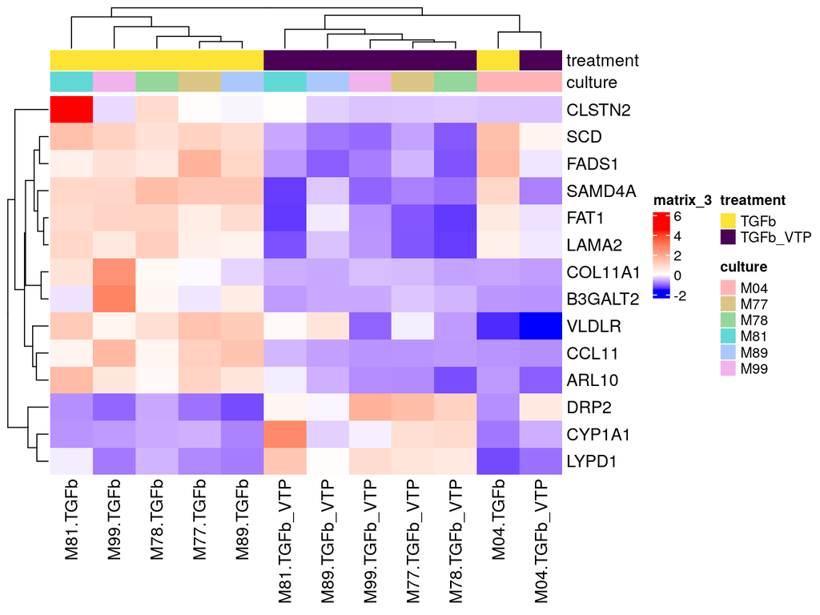

```r
# Extract the differentially expressed genes from the heatmap matrix
heatmap_matrix_vtp_tgf <- heatmap_matrix[rownames(deg_vtp_tgf), grepl("\\.TGFb_VTP|\\.TGFb", colnames(heatmap_matrix))]
# Check the range of the heatmap matrix
hmap_range <- range(heatmap_matrix_vtp_tgf)
# Set the 3 color palette based on the scaled heatmap matrix
hmap_col <- circlize::colorRamp2(c(hmap_range[1], 0, hmap_range[2]), c("blue", "white", "red"))

# Redefine 2 colours for the 4 treatment conditions
treatment_col <- hcl.colors(2, palette = "viridis")
names(treatment_col) <- c("TGFb_VTP", "TGFb")
# Create an annotation dataframe
anno_df <- data.frame(treatment = sample_matrix_sorted[grepl("\\.TGFb_VTP|\\.TGFb", rownames(sample_matrix_sorted)),
    "treatment"], culture = sample_matrix_sorted[grepl("\\.TGFb_VTP|\\.TGFb", rownames(sample_matrix_sorted)),
    "culture"])
anno_col <- list(treatment = treatment_col, culture = culture_col)
# Create the heatmap annotation
hmap_anno <- ComplexHeatmap::HeatmapAnnotation(df = anno_df, col = anno_col)

# Plot the heatmap
hmap_vtp_tgf <- ComplexHeatmap::Heatmap(heatmap_matrix_vtp_tgf, show_row_dend = TRUE, show_column_dend = TRUE,
    show_column_names = TRUE, show_row_names = TRUE, col = hmap_col, top_annotation = hmap_anno)
hmap_vtp_tgf
```

**Figure 6.** Heatmap of differentially expressed genes under VTP treatment in the presence of TGF-β1.

In this comparison, culture `M04` does not show highly consistent expression profiles with the rest of the samples. Rather, the expression seems to be more consistent within the `M04` culture, shown as a single cluster in Figure 6. Among the differentially expressed genes, we can only see a single collagen gene, `COL11A1`, which has a fold change of `9.56`. Other genes are also observed in the previous analysis, but these few genes do not seem to confer a group of related biological processes/functions. Therefore, it means that the VTP treatment may have antifibrotic effects, but the effect is not very significant when a potent fibrotic stimulus, TGF-β1, is present.

# 4 Threshold Over-representation Analysis

To further investigate the changes in the biological processes due to the use of VTP, we will perform a threshold over-representation analysis (t-ORA) on the differentially expressed genes. Gene lists are defined by a thresholded FDR < 0.05 and fold change > 2. We chose this threshold since we want to focus on the major biological pathways that are affected by VTP treatment, rather than mildly affected pathways. Additionally, this threshold is recommended by earlier studies and have been shown to have a stronger emphasis on fibrosis-related pathways (t-ORA using only FDR < 0.05 was performed and shows a more complex but less focused enrichment results, details shown [here](https://github.com/bcb420-2023/Jielin_Yang/wiki/Differential-Gene-Expression-Analysis-and-Preliminary-ORA)).<sup>23</sup>

To perform t-ORA, we employed the web-based [DAVID](https://david.ncifcrf.gov/) tool, which employed Fisher’s Exact test to determine whether the genes of interest in a certain pathway/geneset is higher in comparison to the genes that are not in the geneset.<sup>24</sup> <sup>23</sup> This method allows use to perform a simple enrichment analysis on the gene lists, which we obtained by setting a strict threshold inside differentially expressed genes. The results are also valid for preliminary understanding of the differentially regulated biological processes due to the addition of VTP. To this end, we use the Biological Processes (BP) ontology in GO and the Reactome pathways as the annotation data source.<sup>25</sup> <sup>26</sup> These two annotation data both supports the most up-to-date functional annotation of human genes, and since we are interested in learning about the changes regarding to fibrosis, the use of these two annotation data sources appropriately and sufficiently support the identification of major processes and pathways that are affected by VTP treatment. The [DAVID](https://david.ncifcrf.gov/) knowledgebase was last updated in December 2022, which incorporates `Version 83` of Reactome and the latest release of Gene Ontology (GO).

## 4.1 Effect of VTP under Maximal Strain

### 4.1.1 All Differentially Expressed Genes

We first examine the genesets enriched in the differentially expressed genes comparing VTP treatment to control, in the absense of TGF-β1.

```r
# Extract a gene list with thresholded FDR < 0.05 and fold change > 2
write.table(rownames(deg_vtp_ctrl[deg_vtp_ctrl$logFC > 1 | deg_vtp_ctrl$logFC < -1, ]), file = "./Data/deg_vtp_ctrl_FDR_FC2.txt",
    quote = FALSE, row.names = FALSE, col.names = FALSE)

# Extract a gene list with thresholded FDR < 0.05 and fold change > 2 for up-regulated genes
write.table(rownames(deg_vtp_ctrl[deg_vtp_ctrl$logFC > 1, ]), file = "./Data/deg_vtp_ctrl_FDR_FC2_upreg.txt",
    quote = FALSE, row.names = FALSE, col.names = FALSE)

# Extract a gene list with thresholded FDR < 0.05 and fold change > 2 for down-regulated genes
write.table(rownames(deg_vtp_ctrl[deg_vtp_ctrl$logFC < -1, ]), file = "./Data/deg_vtp_ctrl_FDR_FC2_downreg.txt",
    quote = FALSE, row.names = FALSE, col.names = FALSE)
```

We have exported the gene list to a text file and uploaded it to [DAVID](https://david.ncifcrf.gov/), where we identified the genes by official gene symbols. A multiple test correction was performed using the Benjamini-Hochberg method. The results are exported and analyzed in the following section.

We first examine the enrichment result using all differentially expressed genes with thresholded FDR < 0.05 and fold change > 2. The results are shown in Table 8.

```r
# Import enriched genesets returned by DAVID
genesets_vtp_ctrl <- read.table("./Data/DAVID_deg_vtp_ctrl_FDR_genesets.txt", header = TRUE, sep = "\t", stringsAsFactors = FALSE)
# Split terms into ID and description
genesets_vtp_ctrl$ID <- stringr::str_split_fixed(genesets_vtp_ctrl$Term, "~", 2)[, 1]
genesets_vtp_ctrl$Term <- stringr::str_split_fixed(genesets_vtp_ctrl$Term, "~", 2)[, 2]
# Reorder the Columns and remove unnecessary statistics
genesets_vtp_ctrl <- genesets_vtp_ctrl[, c("Category", "ID", "Term", "Fold.Enrichment", "PValue", "FDR", "Genes",
    "Count", "X.")]
# Visualize the table
DT::datatable(genesets_vtp_ctrl[genesets_vtp_ctrl$FDR < 0.05, 1:6], rownames = FALSE, filter = "top", options = list(pageLength = 5,
    scrollX = TRUE)) %>%
    DT::formatStyle(colnames(genesets_vtp_ctrl)[1:6], fontSize = "12px") %>%
    DT::formatStyle(0, fontSize = "12px")
```

| Category | ID | Term | Fold.Enrichment | PValue | FDR |
| --- | --- | --- | --- | --- | --- |
| REACTOME_PATHWAY | R-HSA-3000171 | Non-integrin membrane-ECM interactions | 5.18549320981156 | 2.60666090297142e-08 | 3.76141168298775e-05 |
| REACTOME_PATHWAY | R-HSA-1474244 | Extracellular matrix organization | 2.3795652173913 | 3.29584014147335e-07 | 0.000237794866207302 |
| REACTOME_PATHWAY | R-HSA-3000157 | Laminin interactions | 6.79875776397516 | 5.16329943703754e-07 | 0.000248354702921506 |
| GOTERM_BP_DIRECT | GO:0007155 | cell adhesion | 2.05130714138348 | 1.04741318469046e-06 | 0.00409224331258565 |
| REACTOME_PATHWAY | R-HSA-3000178 | ECM proteoglycans | 4.02558025498529 | 1.40300079928693e-06 | 0.000506132538342759 |
| REACTOME_PATHWAY | R-HSA-8957275 | Post-translational protein phosphorylation | 3.14757303887739 | 1.48520816223863e-05 | 0.0042863107562207 |
| REACTOME_PATHWAY | R-HSA-9006934 | Signaling by Receptor Tyrosine Kinases | 1.78402517661562 | 3.52657781866663e-05 | 0.00760650813284281 |
| REACTOME_PATHWAY | R-HSA-8874081 | MET activates PTK2 signaling | 5.6656314699793 | 3.68992078516283e-05 | 0.00760650813284281 |
| REACTOME_PATHWAY | R-HSA-199992 | trans-Golgi Network Vesicle Budding | 3.54101966873706 | 6.31553656519731e-05 | 0.0113916490794746 |
| REACTOME_PATHWAY | R-HSA-8875878 | MET promotes cell motility | 4.56014240266626 | 9.71355264759913e-05 | 0.0122592803381944 |

[output cut: 6 more lines]

**Table 8.** Enriched genesets in differentially expressed genes comparing VTP treatment to control, in the absense of TGF-β1. The threshold used for gene list definition is FDR < 0.05 and fold change > 2.

A total of `209` genesets are enriched in this analysis, which includes `16` genesets determined to be significant after multiple test correction. The top 5 enriched genesets are related to extracellular matrix organization and cell adhesion processes.

### 4.1.2 Up-regulated Genes in VTP

We further perform threshold over-representation analysis on the up-regulated genes and down-regulated genes under VTP treatment separately, with results shown in Table 9 and Table 10, respectively. The same threshold was used for gene list definition as in the previous section.

```r
# Import enriched genesets returned by DAVID
genesets_vtp_ctrl_upreg <- read.table("./Data/DAVID_deg_vtp_ctrl_FDR_upreg_genesets.txt", header = TRUE, sep = "\t",
    stringsAsFactors = FALSE)
# Split terms into ID and description
genesets_vtp_ctrl_upreg$ID <- stringr::str_split_fixed(genesets_vtp_ctrl_upreg$Term, "~", 2)[, 1]
genesets_vtp_ctrl_upreg$Term <- stringr::str_split_fixed(genesets_vtp_ctrl_upreg$Term, "~", 2)[, 2]
# Reorder the Columns and remove unnecessary statistics
genesets_vtp_ctrl_upreg <- genesets_vtp_ctrl_upreg[, c("Category", "ID", "Term", "Fold.Enrichment", "PValue",
    "FDR", "Genes", "Count", "X.")]
# Visualize the table
DT::datatable(genesets_vtp_ctrl_upreg[genesets_vtp_ctrl_upreg$FDR < 0.05, 1:6], rownames = FALSE, filter = "top",
    options = list(pageLength = 5, scrollX = TRUE)) %>%
    DT::formatStyle(colnames(genesets_vtp_ctrl_upreg)[1:6], fontSize = "12px") %>%
    DT::formatStyle(0, fontSize = "12px")
```

| Category | ID | Term | Fold.Enrichment | PValue | FDR |
| --- | --- | --- | --- | --- | --- |
| REACTOME_PATHWAY | R-HSA-8953897 | Cellular responses to stimuli | 2.10007290587468 | 2.09478378668541e-07 | 0.000219742819223299 |
| REACTOME_PATHWAY | R-HSA-2262752 | Cellular responses to stress | 2.0596152275866 | 6.82924758919745e-07 | 0.000358194036053406 |
| GOTERM_BP_DIRECT | GO:0006412 | translation | 3.46780269058296 | 3.08421332528872e-06 | 0.00704125902163415 |
| REACTOME_PATHWAY | R-HSA-9711123 | Cellular response to chemical stress | 3.23558971327224 | 7.32264036112399e-06 | 0.00256048324627302 |
| GOTERM_BP_DIRECT | GO:0032543 | mitochondrial translation | 4.98668650793651 | 1.09484523915218e-05 | 0.0124976584049221 |
| REACTOME_PATHWAY | R-HSA-8953854 | Metabolism of RNA | 1.96984492120871 | 1.43835152669461e-05 | 0.00343730165536944 |
| GOTERM_BP_DIRECT | GO:0009060 | aerobic respiration | 5.78674829931973 | 1.81020513733084e-05 | 0.0137756610950877 |
| REACTOME_PATHWAY | R-HSA-5419276 | Mitochondrial translation termination | 4.58153836247143 | 2.29371893113309e-05 | 0.00343730165536944 |
| REACTOME_PATHWAY | R-HSA-5368286 | Mitochondrial translation initiation | 4.58153836247143 | 2.29371893113309e-05 | 0.00343730165536944 |
| REACTOME_PATHWAY | R-HSA-5389840 | Mitochondrial translation elongation | 4.58153836247143 | 2.29371893113309e-05 | 0.00343730165536944 |

[output cut: 13 more lines]

**Table 9.** Enriched genesets in up-regulated genes comparing VTP treatment to control.

In upregulated genes alone, we observed `64` genesets enriched, including `23` genesets significantly enriched after multiple test correction. As espected, we observed enriched pathways pertaining to cellular response to exogenous stimulus, which is consistant with the fact these are upregulated genes for samples treated with VTP.

### 4.1.3 Down-regulated Genes in VTP

```r
# Import enriched genesets returned by DAVID
genesets_vtp_ctrl_downreg <- read.table("./Data/DAVID_deg_vtp_ctrl_FDR_downreg_genesets.txt",
                                     header = TRUE, sep = "\t", stringsAsFactors = FALSE)
# Split terms into ID and description
genesets_vtp_ctrl_downreg$ID <- stringr::str_split_fixed(genesets_vtp_ctrl_downreg$Term, "~", 2)[, 1]
genesets_vtp_ctrl_downreg$Term <- stringr::str_split_fixed(genesets_vtp_ctrl_downreg$Term, "~", 2)[, 2]
# Reorder the Columns and remove unnecessary statistics
genesets_vtp_ctrl_downreg <- genesets_vtp_ctrl_downreg[,
              c("Category", "ID", "Term", "Fold.Enrichment", "PValue", "FDR", "Genes", "Count")]
# Visualize the table
DT::datatable(genesets_vtp_ctrl_downreg[genesets_vtp_ctrl_downreg$FDR < 0.05,1:6],
        rownames = FALSE, filter = "top",
        options = list(pageLength = 5, scrollX = TRUE)) %>%
        DT::formatStyle(colnames(genesets_vtp_ctrl_downreg)[1:6], fontSize = "12px") %>%
        DT::formatStyle(0, fontSize = "12px")
```

| Category | ID | Term | Fold.Enrichment | PValue | FDR |
| --- | --- | --- | --- | --- | --- |
| REACTOME_PATHWAY | R-HSA-1474244 | Extracellular matrix organization | 5.08524970963995 | 4.62830989004027e-17 | 3.85538213840354e-14 |
| GOTERM_BP_DIRECT | GO:0007155 | cell adhesion | 4.08769075197647 | 2.02285965838127e-15 | 5.05108056697804e-12 |
| REACTOME_PATHWAY | R-HSA-3000171 | Non-integrin membrane-ECM interactions | 11.6357408610406 | 7.9394993214253e-14 | 3.30680146737364e-11 |
| REACTOME_PATHWAY | R-HSA-3000178 | ECM proteoglycans | 9.03300935264992 | 7.33104524273408e-12 | 2.0355868957325e-09 |
| REACTOME_PATHWAY | R-HSA-3000157 | Laminin interactions | 15.2557491289199 | 1.12446780472906e-10 | 2.34170420334827e-08 |
| REACTOME_PATHWAY | R-HSA-8957275 | Post-translational protein phosphorylation | 6.70970447799716 | 3.1709274499165e-10 | 5.28276513156088e-08 |
| REACTOME_PATHWAY | R-HSA-381426 | Regulation of Insulin-like Growth Factor (IGF) transport and uptake | 5.79718466898955 | 3.65898674489095e-09 | 5.07989326415694e-07 |
| GOTERM_BP_DIRECT | GO:0030335 | positive regulation of cell migration | 4.29672039270254 | 2.31069363598387e-08 | 2.79487944707539e-05 |
| GOTERM_BP_DIRECT | GO:0007160 | cell-matrix adhesion | 6.9138613389281 | 3.35788479824837e-08 | 2.79487944707539e-05 |
| REACTOME_PATHWAY | R-HSA-216083 | Integrin cell surface interactions | 6.73047755687641 | 3.61992233069051e-08 | 4.30770757352171e-06 |

[output cut: 51 more lines]

**Table 10.** Enriched genesets in down-regulated genes comparing VTP treatment to control.

In down-regulated genes alone, we observed `353` genesets enriched, with `61` being significant by FDR. Interestingly, using downregulated genes only, we observed even more enriched genesets compared to using the whole list of differentially expressed genes. Since the down-regulated and up-regulated genes are likely to be involved in very different processes, using the whole list for enrichment analysis likely reduces the fraction of the set of genes involved in a common pathway. Therefore, using Fisher’s Exact Test may not be able to detect many other less significant pathways. This observation is supported by a lower p-value observed in the separately performed ORA.

### 4.1.4 Analysis

We will now draw a dotplot to visualize the top 10 genesets enriched in the up and diown-regualted genes.

```r
# Subset the top 10 genesets enricheds
gs_upreg_10 <- genesets_vtp_ctrl_upreg[order(genesets_vtp_ctrl_upreg$FDR), ] %>% head(10)
gs_downreg_10 <- genesets_vtp_ctrl_downreg[order(genesets_vtp_ctrl_downreg$FDR), ] %>% head(10)

# Calculate gene ratio
gs_upreg_10$gene_ratio <- gs_upreg_10$Count / nrow(deg_vtp_ctrl[deg_vtp_ctrl$logFC > 1, ])
gs_upreg_10 <- gs_upreg_10[order(gs_upreg_10$gene_ratio, decreasing = TRUE), ]
gs_downreg_10$gene_ratio <- gs_downreg_10$Count / nrow(deg_vtp_ctrl[deg_vtp_ctrl$logFC < -1, ])
gs_downreg_10 <- gs_downreg_10[order(gs_downreg_10$gene_ratio, decreasing = TRUE), ]
```

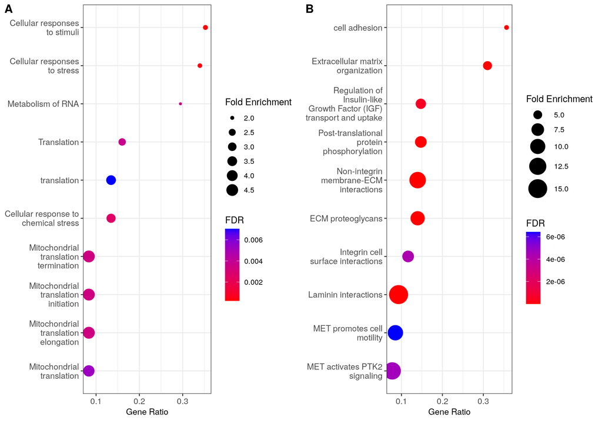

```r
# Dotplot of the top genesets enriched in the up-regulated genes
# We plot it with ggplot2, with each term against the gene ratio
# The size of the dot is proportional to the fold enrichment
plot_upreg <- ggplot2::ggplot(gs_upreg_10) +
                ggplot2::geom_point(ggplot2::aes(x = gene_ratio,
                            y = reorder(stringr::str_wrap(Term, 20), gene_ratio),
                            color = FDR,
                            size = Fold.Enrichment)) +
                ggplot2::theme_bw() +
                ggplot2::theme(axis.text.x = ggplot2::element_text(size = 10),
                               axis.text.y = ggplot2::element_text(size = 10),
                               axis.title.x = ggplot2::element_text(size = 10),
                               axis.title.y = ggplot2::element_text(size = 10)) +
                ggplot2::scale_color_gradient(low = "red", high = "blue") +
                ggplot2::labs(x = "Gene Ratio", y = NULL,
                              color = "FDR", size = "Fold Enrichment")

# Dotplot of the top genesets enriched in the down-regulated genes
plot_downreg <- ggplot2::ggplot(gs_downreg_10) +
                ggplot2::geom_point(ggplot2::aes(x = gene_ratio,
                               y = reorder(stringr::str_wrap(Term, 20), gene_ratio),
                               color = FDR,
                               size = Fold.Enrichment)) +
                ggplot2::theme_bw() +
                ggplot2::theme(axis.text.x = ggplot2::element_text(size = 10),
                               axis.text.y = ggplot2::element_text(size = 10),
                               axis.title.x = ggplot2::element_text(size = 10),
                               axis.title.y = ggplot2::element_text(size = 10)) +
                ggplot2::scale_color_gradient(low = "red", high = "blue") +
                ggplot2::scale_size(range = c(2, 10)) +
                ggplot2::labs(x = "Gene Ratio", y = NULL,
                              color = "FDR", size = "Fold Enrichment")

# Draw the plots
cowplot::plot_grid(plot_upreg, plot_downreg, ncol = 2, labels = "AUTO")
```

**Figure 7.** Top 10 enriched genesets in A) up-regulated and B) down-regulated genes comparing VTP treatment to control. Colour of the dots indicates significance level, and the size indicates the fold enrichment.

Comparatively, a higher number of genesets were enriched in the down-regulated genes, with higher fold change and stronger signficiance level. As expected, the use of VTP as an inhibitory drug should result in a stronger down-regulation of genes rather than up-regulation. Figure 7B. shows that the most signifiantly enriched genesets are involved in cell adhesion and extracellular matrix. While no previous studies, except the authors of the dataset, have established the connection between VTP and ECM remodeling, it has been well established that the formation of cardiac fibrosis with elevated level of fibroblasts are associated with an increased level of collagen depostion, integrin mediated cell adhesion, and the cellular cross-talks via the ECM.<sup>27</sup> Therefore, our result support the proposed mechanism that VTP inhibition of the YAP/TAZ complex of fribroblast precursors (i.e., cardiac stromoal cells) prevents the initiation of fibroblast differentiation and ECM remodeling.<sup>1</sup> Additional genesets that are downregulated includes insulin-like growth factor (IGF) transport and updake, which may seem to be unrelated in terms of cardiac fibrosis. However, IGF is a potent mitogen that is involved in the proliferation of cardiac fibroblasts, and its roles as a downstream target of YAP/TAZ has been well established in cardiac development since the embryonic stage.<sup>28</sup> Therefore, the result of our analysis supports the mechanism that VTP inhibition on YAP/TAZ complex is a potential strategy to prevent cardiac fibrosis under pathological straining conditions. The upregulated genesets are likely a response to the exogenous stress posed by the introduction of VTP into the culture media.

However, based on the few differentially expressed genes in the presence of the potent profibrotic cytokine TGF-β1, no genesets were found enriched in any of the gene lists, regardless of threhold used. This means that VTP treamtent alone may not be sufficient to revoke the profibrotic effects of TGF-β1. This is likely due to the fact that TGF-β1 acts through Smad-dependent and independent pathways, where Smad is also an interacting partner of YAP/TAZ.<sup>29</sup> Therefore, the antifibrotic effect of VTP is dependent on the environment of what types of pro-fibrotic signals are present.

# 5 Interpretation and Analysis

## 5.1 Differential Gene Expression Analysis

- **How many genes were significantly differentially expressed? What thresholds did you use and why?**

  Based on unadjusted p-value, 3651 genes have unadjusted p-value < 0.05 when comparing VTP treatment to control. When TGF-β1 is present, 1602 genes have unadjusted p-value < 0.05.

  For details and reasons, see differential gene expression analysis without TGF-β1 here and with TGF-β1 here.
- **Multiple hypothesis testing - correct your p-values using a multiple hypothesis correction method. Which method did you use? And Why? How many genes passed correction?**

  In the case of comparison between VTP and control without TGF-β1, 1040 are differentially expressed. A threshold of BH-adjusted p-value (FDR) < 0.05 was used to determine significance. This is a common threshold used, which limits an acceptable false discovery rate and is not too stringent that may eliminate too many genes that may have a biological significance. When TGF-β1 is present, 14 genes are differentially expressed. The same threshold was used to determine significance.

  For details and reasons, see how multiple tests are corrected here and here.
- **Show the amount of differentially expressed genes using an MA Plot or a Volcano plot. Highlight genes of interest.**

  See Figure 4.
- **Visualize your top hits using a heatmap. Do you conditions cluster together? Explain why or why not.**

  See Figure 5 and Figure 6.

## 5.2 Threshold Over-representation Analysis

- **Which method did you choose and why?**

  We employed Fisher’s Exact Test to determine the significance of the enrichment of genesets in all cases memtioneed previously. This is the method used by the DAVID tool and is a can commonly be used for threshold over-representation analysis based on hypergeometric distribution.

  For detials and reasons, see here.
- **What annotation data did you use and why? What version of the annotation are you using?**

  We used the GO Biological Process and Reactome as the source annotation data, which are accessed from the DAVID tool.

  For details and reasons, see here.
- **How many genesets were returned with what thresholds?**

  We use a threshold of BH-adjusted p-value (FDR) < 0.05 and a fold change > 2 to extract the list of differentially expressed genes for functional enrichment analysis. Without separating the up-regulated and down-regulated genes, we obtained 209 genesets.

  For more details, see Table 8.
- **Run the analysis using the up-regulated set of genes, and the down-regulated set of genes separately. How do these results compare to using the whole list (i.e all differentially expressed genes together vs. the up-regulated and down regulated differentially expressed genes separately)?**

  For more details, see Table 8, Table 9, Table 10, and Figure 7.

## 5.3 Result Interpretation

- **Do the over-representation results support conclusions or mechanism discussed in the original paper?**

  Yes. Based on the result of the differential gene expression analysis, we found that VTP treatment significantly down-regulates genes involved in cell adhesion and extracellular matrix remodeling, which are consistent with the proposed mechanism that VTP inhibits the YAP/TAZ complex of fibroblast precursors (i.e., cardiac stromal cells) to prevent the initiation of fibroblast differentiation and ECM remodeling.

  See discussion here.
- **Can you find evidence, i.e. publications, to support some of the results that you see. How does this evidence support your results.**

  See discussion here.

# 6 Journal Link

The link to the concurrent journal entry can be found [here](https://github.com/bcb420-2023/Jielin_Yang/wiki/Differential-Gene-Expression-Analysis-and-Preliminary-ORA).

# References

1.

Garoffolo G, Casaburo M, Amadeo F, et al. Reduction of cardiac fibrosis by interference with YAP-dependent transactivation. *Circulation Research*. 2022;131(3):239-257.

2.

Porter KE, Turner NA. Cardiac fibroblasts: At the heart of myocardial remodeling. *Pharmacology & therapeutics*. 2009;123(2):255-278.

3.

Tallquist MD, Molkentin JD. Redefining the identity of cardiac fibroblasts. *Nature Reviews Cardiology*. 2017;14(8):484-491.

4.

Elosegui-Artola A, Andreu I, Beedle AE, et al. Force triggers YAP nuclear entry by regulating transport across nuclear pores. *Cell*. 2017;171(6):1397-1410.

5.

Panciera T, Azzolin L, Cordenonsi M, Piccolo S. Mechanobiology of YAP and TAZ in physiology and disease. *Nature reviews Molecular cell biology*. 2017;18(12):758-770.

6.

Brusatin G, Panciera T, Gandin A, Citron A, Piccolo S. Biomaterials and engineered microenvironments to control YAP/TAZ-dependent cell behaviour. *Nature materials*. 2018;17(12):1063-1075.

7.

Saadat S, Noureddini M, Mahjoubin-Tehran M, et al. Pivotal role of TGF-$\beta$/smad signaling in cardiac fibrosis: Non-coding RNAs as effectual players. *Frontiers in cardiovascular medicine*. 2021;7:588347.

8.

Durinck S, Spellman PT, Birney E, Huber W. Mapping identifiers for the integration of genomic datasets with the r/bioconductor package biomaRt. *Nature protocols*. 2009;4(8):1184-1191.

9.

Robinson MD, McCarthy DJ, Smyth GK. edgeR: A bioconductor package for differential expression analysis of digital gene expression data. *bioinformatics*. 2010;26(1):139-140.

10.

Walker EJ, Heydet D, Veldre T, Ghildyal R. Transcriptomic changes during TGF-$\beta$-mediated differentiation of airway fibroblasts to myofibroblasts. *Scientific reports*. 2019;9(1):20377.

11.

Gu Z, Eils R, Schlesner M. Complex heatmaps reveal patterns and correlations in multidimensional genomic data. *Bioinformatics*. 2016;32(18):2847-2849.

12.

Gu Z, Gu L, Eils R, Schlesner M, Brors B. Circlize implements and enhances circular visualization in r. *Bioinformatics*. 2014;30(19):2811-2812.

13.

Sharko J, Grinstein GG, Marx KA, et al. Heat map visualizations allow comparison of multiple clustering results and evaluation of dataset quality: Application to microarray data. In: *2007 11th International Conference Information Visualization (IV’07)*. IEEE; 2007:521-526.

14.

Lun AT, Chen Y, Smyth GK. It’s DE-licious: A recipe for differential expression analyses of RNA-seq experiments using quasi-likelihood methods in edgeR. *Statistical genomics: methods and protocols*. Published online 2016:391-416.

15.

McCarthy DJ, Chen Y, Smyth GK. Differential expression analysis of multifactor RNA-seq experiments with respect to biological variation. *Nucleic acids research*. 2012;40(10):4288-4297.

16.

Ritchie ME, Phipson B, Wu D, et al. Limma powers differential expression analyses for RNA-sequencing and microarray studies. *Nucleic acids research*. 2015;43(7):e47-e47.

17.

Ahmed A, Syed JN, Chi L, et al. KDM8 epigenetically controls cardiac metabolism to prevent initiation of dilated cardiomyopathy. *Nature Cardiovascular Research*. Published online 2023:1-18.

18.

Korthauer K, Kimes PK, Duvallet C, et al. A practical guide to methods controlling false discoveries in computational biology. *Genome biology*. 2019;20(1):1-21.

19.

Moore-Morris T, Guimarães-Camboa N, Banerjee I, et al. Resident fibroblast lineages mediate pressure overload–induced cardiac fibrosis. *The Journal of clinical investigation*. 2014;124(7):2921-2934.

20.

Nwogu JI, Geenen D, Bean M, Brenner MC, Huang X, Buttrick PM. Inhibition of collagen synthesis with prolyl 4-hydroxylase inhibitor improves left ventricular function and alters the pattern of left ventricular dilatation after myocardial infarction. *Circulation*. 2001;104(18):2216-2221.

21.

Pizzagalli MD, Bensimon A, Superti-Furga G. A guide to plasma membrane solute carrier proteins. *The FEBS journal*. 2021;288(9):2784-2835.

22.

Totaro A, Panciera T, Piccolo S. YAP/TAZ upstream signals and downstream responses. *Nature cell biology*. 2018;20(8):888-899.

23.

Reimand J, Isserlin R, Voisin V, et al. Pathway enrichment analysis and visualization of omics data using g: Profiler, GSEA, cytoscape and EnrichmentMap. *Nature protocols*. 2019;14(2):482-517.

24.

Huang DW, Sherman BT, Lempicki RA. Systematic and integrative analysis of large gene lists using DAVID bioinformatics resources. *Nature protocols*. 2009;4(1):44-57.

25.

Ashburner M, Ball CA, Blake JA, et al. Gene ontology: Tool for the unification of biology. *Nature genetics*. 2000;25(1):25-29.

26.

Vastrik I, D’Eustachio P, Schmidt E, et al. Reactome: A knowledge base of biologic pathways and processes. *Genome biology*. 2007;8:1-13.

27.

Bowers SL, Meng Q, Molkentin JD. Fibroblasts orchestrate cellular crosstalk in the heart through the ECM. *Nature Cardiovascular Research*. 2022;1(4):312-321.

28.

Xin M, Kim Y, Sutherland LB, et al. Regulation of insulin-like growth factor signaling by yap governs cardiomyocyte proliferation and embryonic heart size. *Science signaling*. 2011;4(196):ra70-ra70.

29.

Aashaq S, Batool A, Mir SA, Beigh MA, Andrabi KI, Shah ZA. TGF-$\beta$ signaling: A recap of SMAD-independent and SMAD-dependent pathways. *Journal of Cellular Physiology*. 2022;237(1):59-85.